# Laboratorio 2: DIAGRAMA DE DISPERSIÓN. INTERPRETACIÓN

Aranda, Milene - Escriba, Daniel - Fernandez, Wilmer

2025-03-26

# Introduccion

Los datos mostrados corresponden a la proporción del volumen de ventas de las pantallas de preabordaje en aeropuertos en EE. UU. Entre 1988 y 1999, y las violaciones de seguridad detectada por millones de pasajeros. Con respecto a lo anterior, haga lo siguiente:

# Parte A

Traslade la información de la tabla mostrada a un documento de texto y asígnele el nombre ‘seguridad.txt’.

- Se adjunta el archivo

# Parte B

- Lea la base de datos y haga un resumen de los principales estadísticos descriptivos.

```r
data = read.table("seguridad.txt", sep="", header=T)
data
```

```
##           Ciudad Volumen_de_ventas Violaciones
## 1       St.Louis               416        11.9
## 2        Atlanta               375         7.3
## 3        Houston               237        10.6
## 4         Boston               207        22.9
## 5        Chicago               200         6.5
## 6         Denver               193        15.2
## 7         Dallas               156        18.2
## 8      Baltimore               155        21.7
## 9  Seatle/Tacoma               140        31.5
## 10 San_Francisco               110        20.7
```

```r
summary(data)
```

```
##     Ciudad          Volumen_de_ventas  Violaciones
##  Length:10          Min.   :110.0     Min.   : 6.50
##  Class :character   1st Qu.:155.2     1st Qu.:10.93
##  Mode  :character   Median :196.5     Median :16.70
##                     Mean   :218.9     Mean   :16.65
##                     3rd Qu.:229.5     3rd Qu.:21.45
##                     Max.   :416.0     Max.   :31.50
```

# Parte C

Elabora un diagrama de dispersión considerando a la variable X como el volumen de ventas e Y como las violaciones. Además, a partir del gráfico realice una interpretación de la relación entre las variables.

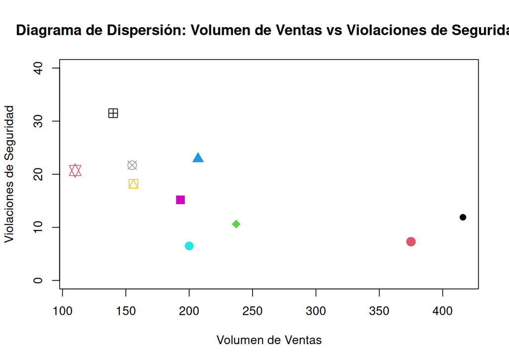

```r
plot(data$Volumen_de_ventas, data$Violaciones,
main = "Diagrama de Dispersión: Volumen de Ventas vs Violaciones de Seguridad",
xlab = "Volumen de Ventas",
ylab = "Violaciones de Seguridad",
pch = 20:11, col = 1:10, cex=1.6,
ylim = c(0, 40))
```

## Interpretacion

- El análisis visual del gráfico revela un panorama complejo en la relación entre el volumen de ventas de pantallas de preabordaje y las violaciones de seguridad. A primera vista, la correlación no es inmediatamente evidente ni estadísticamente robusta.
- Sin embargo, se observa un patrón intrigante que sugiere una posible relación inversa: conforme aumenta la venta de pantallas de preabordaje, se aprecia una ligera tendencia a la disminución en el número de violaciones de seguridad. Esta observación preliminar es sugerente, pero no concluyente.

Recomendaciones:

- Realizar un análisis estadístico riguroso , considerar variables intervinientes que puedan influir en esta aparente relación y recopilar datos adicionales para aumentar la solidez del análisis